# STDS AT2B Model Building

Here is a new model that I’ve been playing with. Please review and comment if this makes sense.

```
## here() starts at N:/Data_Work/20200808 36103 Statistical Thinking for DS/AT2/STDS_Data_Geeks_Agriculture
```

[output not shown]

```
## Google's Terms of Service: https://cloud.google.com/maps-platform/terms/.
```

# Data Loading

## Loading - Yield

```r
### loading, tidying and merging datasets ###
### yield data ###
# Reading csv file and skipping the first 4 rows then assigning to tibble (yield_area_raw)
# (Data from: https://www.abs.gov.au/AUSSTATS/abs@.nsf/DetailsPage/7121.02015-16?OpenDocument) - link doesn't work
# Explanation of Australian Statistical Geography Standard (ASGS) regions https://www.abs.gov.au/websitedbs/d3310114.nsf/home/australian+statistical+geography+standard+(asgs)

yield_area_raw <- read_csv(here::here("project/src/data/yield", "7121DO004_201516.csv"), skip = 4)
```

## Loading - Gridded Climate Raster Data

```r
mean_temp_annual <- raster(here("project/src/data/BOM_climate/mean_temperature", "meanann.txt"))
mean_temp_winter <- raster(here("project/src/data/BOM_climate/mean_temperature", "meanmaysep.txt"))
mean_temp_summer <- raster(here("project/src/data/BOM_climate/mean_temperature", "meanoctapr.txt"))

max_temp_annual <- raster(here("project/src/data/BOM_climate/max_temperature", "maxann.txt"))
max_temp_winter <- raster(here("project/src/data/BOM_climate/max_temperature", "maxmaysep.txt"))
max_temp_summer <- raster(here("project/src/data/BOM_climate/max_temperature", "maxoctapr.txt"))

min_temp_annual <- raster(here("project/src/data/BOM_climate/min_temperature", "minann.txt"))
min_temp_winter <- raster(here("project/src/data/BOM_climate/min_temperature", "minmaysep.txt"))
min_temp_summer <- raster(here("project/src/data/BOM_climate/min_temperature", "minoctapr.txt"))

mean_temp_jan <- raster(here("project/src/data/BOM_climate/monthly_mean_temp", "meanjan.txt"))
mean_temp_feb <- raster(here("project/src/data/BOM_climate/monthly_mean_temp", "meanfeb.txt"))
mean_temp_mar <- raster(here("project/src/data/BOM_climate/monthly_mean_temp", "meanmar.txt"))
mean_temp_apr <- raster(here("project/src/data/BOM_climate/monthly_mean_temp", "meanapr.txt"))
mean_temp_may <- raster(here("project/src/data/BOM_climate/monthly_mean_temp", "meanmay.txt"))
mean_temp_jun <- raster(here("project/src/data/BOM_climate/monthly_mean_temp", "meanjun.txt"))
mean_temp_jul <- raster(here("project/src/data/BOM_climate/monthly_mean_temp", "meanjul.txt"))
mean_temp_aug <- raster(here("project/src/data/BOM_climate/monthly_mean_temp", "meanaug.txt"))
mean_temp_sep <- raster(here("project/src/data/BOM_climate/monthly_mean_temp", "meansep.txt"))
mean_temp_oct <- raster(here("project/src/data/BOM_climate/monthly_mean_temp", "meanoct.txt"))
mean_temp_nov <- raster(here("project/src/data/BOM_climate/monthly_mean_temp", "meannov.txt"))
mean_temp_dec <- raster(here("project/src/data/BOM_climate/monthly_mean_temp", "meandec.txt"))

mean_rain_annual <- raster(here("project/src/data/BOM_climate/mean_rainfall", "rnozan.txt"))
mean_rain_dry <- raster(here("project/src/data/BOM_climate/mean_rainfall", "rnozdry.txt"))
mean_rain_wet <- raster(here("project/src/data/BOM_climate/mean_rainfall", "rnozwet.txt"))

mean_rain_jan <- raster(here("project/src/data/BOM_climate/monthly_mean_rainfall", "rainjan.txt"))
mean_rain_feb <- raster(here("project/src/data/BOM_climate/monthly_mean_rainfall", "rainfeb.txt"))
mean_rain_mar <- raster(here("project/src/data/BOM_climate/monthly_mean_rainfall", "rainmar.txt"))
mean_rain_apr <- raster(here("project/src/data/BOM_climate/monthly_mean_rainfall", "rainapr.txt"))
mean_rain_may <- raster(here("project/src/data/BOM_climate/monthly_mean_rainfall", "rainmay.txt"))
mean_rain_jun <- raster(here("project/src/data/BOM_climate/monthly_mean_rainfall", "rainjun.txt"))
mean_rain_jul <- raster(here("project/src/data/BOM_climate/monthly_mean_rainfall", "rainjul.txt"))
mean_rain_aug <- raster(here("project/src/data/BOM_climate/monthly_mean_rainfall", "rainaug.txt"))
mean_rain_sep <- raster(here("project/src/data/BOM_climate/monthly_mean_rainfall", "rainsep.txt"))
mean_rain_oct <- raster(here("project/src/data/BOM_climate/monthly_mean_rainfall", "rainoct.txt"))
mean_rain_nov <- raster(here("project/src/data/BOM_climate/monthly_mean_rainfall", "rainnov.txt"))
mean_rain_dec <- raster(here("project/src/data/BOM_climate/monthly_mean_rainfall", "raindec.txt"))

mean_solar_annual <- raster(here("project/src/data/BOM_climate/solar_exposure", "solaran.txt"))
mean_solar_dry <- raster(here("project/src/data/BOM_climate/solar_exposure", "solardry.txt"))
mean_solar_wet <- raster(here("project/src/data/BOM_climate/solar_exposure", "solarwet.txt"))
```

## Loading - Gridded Soil Raster Data

```r
bulk_density <- raster(here("project/src/data/soil", "bulk_density.tif"))
carbon <- raster(here("project/src/data/soil", "carbon.tif"))
clay <- raster(here("project/src/data/soil", "clay.tif"))
nitrogen <- raster(here("project/src/data/soil", "nitrogen.tif"))
ph <- raster(here("project/src/data/soil", "ph.tif"))
phosphorus <- raster(here("project/src/data/soil", "phosphorus.tif"))
sand <- raster(here("project/src/data/soil", "sand.tif"))
silt <- raster(here("project/src/data/soil", "silt.tif"))
water_capacity <- raster(here("project/src/data/soil", "water_capacity.tif"))
```

## Loading - CRS Projection for the rasters

```r
crs(mean_temp_annual) <- sp::CRS("+proj=longlat +ellps=WGS84 +datum=WGS84 +no_defs")
crs(mean_temp_winter) <-sp::CRS("+proj=longlat +ellps=WGS84 +datum=WGS84 +no_defs")
crs(mean_temp_summer) <- sp::CRS("+proj=longlat +ellps=WGS84 +datum=WGS84 +no_defs")
crs(max_temp_annual) <- sp::CRS("+proj=longlat +ellps=WGS84 +datum=WGS84 +no_defs")
crs(max_temp_winter) <-sp::CRS("+proj=longlat +ellps=WGS84 +datum=WGS84 +no_defs")
crs(max_temp_summer) <- sp::CRS("+proj=longlat +ellps=WGS84 +datum=WGS84 +no_defs")
crs(min_temp_annual) <- sp::CRS("+proj=longlat +ellps=WGS84 +datum=WGS84 +no_defs")
crs(min_temp_winter) <- sp::CRS("+proj=longlat +ellps=WGS84 +datum=WGS84 +no_defs")
crs(min_temp_summer) <- sp::CRS("+proj=longlat +ellps=WGS84 +datum=WGS84 +no_defs")
crs(mean_rain_annual) <- sp::CRS("+proj=longlat +ellps=WGS84 +datum=WGS84 +no_defs")
crs(mean_rain_dry) <- sp::CRS("+proj=longlat +ellps=WGS84 +datum=WGS84 +no_defs")
crs(mean_rain_wet) <- sp::CRS("+proj=longlat +ellps=WGS84 +datum=WGS84 +no_defs")
crs(mean_solar_annual) <- sp::CRS("+proj=longlat +ellps=WGS84 +datum=WGS84 +no_defs")
crs(mean_solar_dry) <- sp::CRS("+proj=longlat +ellps=WGS84 +datum=WGS84 +no_defs")
crs(mean_solar_wet) <- sp::CRS("+proj=longlat +ellps=WGS84 +datum=WGS84 +no_defs")
crs(bulk_density) <- sp::CRS("+proj=longlat +ellps=WGS84 +datum=WGS84 +no_defs")
crs(carbon) <- sp::CRS("+proj=longlat +ellps=WGS84 +datum=WGS84 +no_defs")
crs(clay) <- sp::CRS("+proj=longlat +ellps=WGS84 +datum=WGS84 +no_defs")
crs(nitrogen) <- sp::CRS("+proj=longlat +ellps=WGS84 +datum=WGS84 +no_defs")
crs(ph) <- sp::CRS("+proj=longlat +ellps=WGS84 +datum=WGS84 +no_defs")
crs(phosphorus) <- sp::CRS("+proj=longlat +ellps=WGS84 +datum=WGS84 +no_defs")
crs(sand) <- sp::CRS("+proj=longlat +ellps=WGS84 +datum=WGS84 +no_defs")
crs(silt) <- sp::CRS("+proj=longlat +ellps=WGS84 +datum=WGS84 +no_defs")
crs(water_capacity) <- sp::CRS("+proj=longlat +ellps=WGS84 +datum=WGS84 +no_defs")
crs(mean_rain_jan) <- sp::CRS("+proj=longlat +ellps=WGS84 +datum=WGS84 +no_defs")
crs(mean_rain_feb) <- sp::CRS("+proj=longlat +ellps=WGS84 +datum=WGS84 +no_defs")
crs(mean_rain_mar) <- sp::CRS("+proj=longlat +ellps=WGS84 +datum=WGS84 +no_defs")
crs(mean_rain_apr) <- sp::CRS("+proj=longlat +ellps=WGS84 +datum=WGS84 +no_defs")
crs(mean_rain_may) <- sp::CRS("+proj=longlat +ellps=WGS84 +datum=WGS84 +no_defs")
crs(mean_rain_jun) <- sp::CRS("+proj=longlat +ellps=WGS84 +datum=WGS84 +no_defs")
crs(mean_rain_jul) <- sp::CRS("+proj=longlat +ellps=WGS84 +datum=WGS84 +no_defs")
crs(mean_rain_aug) <- sp::CRS("+proj=longlat +ellps=WGS84 +datum=WGS84 +no_defs")
crs(mean_rain_sep) <- sp::CRS("+proj=longlat +ellps=WGS84 +datum=WGS84 +no_defs")
crs(mean_rain_oct) <- sp::CRS("+proj=longlat +ellps=WGS84 +datum=WGS84 +no_defs")
crs(mean_rain_nov) <- sp::CRS("+proj=longlat +ellps=WGS84 +datum=WGS84 +no_defs")
crs(mean_rain_dec) <- sp::CRS("+proj=longlat +ellps=WGS84 +datum=WGS84 +no_defs")
crs(mean_temp_jan) <- sp::CRS("+proj=longlat +ellps=WGS84 +datum=WGS84 +no_defs")
crs(mean_temp_feb) <- sp::CRS("+proj=longlat +ellps=WGS84 +datum=WGS84 +no_defs")
crs(mean_temp_mar) <- sp::CRS("+proj=longlat +ellps=WGS84 +datum=WGS84 +no_defs")
crs(mean_temp_apr) <- sp::CRS("+proj=longlat +ellps=WGS84 +datum=WGS84 +no_defs")
crs(mean_temp_may) <- sp::CRS("+proj=longlat +ellps=WGS84 +datum=WGS84 +no_defs")
crs(mean_temp_jun) <- sp::CRS("+proj=longlat +ellps=WGS84 +datum=WGS84 +no_defs")
crs(mean_temp_jul) <- sp::CRS("+proj=longlat +ellps=WGS84 +datum=WGS84 +no_defs")
crs(mean_temp_aug) <- sp::CRS("+proj=longlat +ellps=WGS84 +datum=WGS84 +no_defs")
crs(mean_temp_sep) <- sp::CRS("+proj=longlat +ellps=WGS84 +datum=WGS84 +no_defs")
crs(mean_temp_oct) <- sp::CRS("+proj=longlat +ellps=WGS84 +datum=WGS84 +no_defs")
crs(mean_temp_nov) <- sp::CRS("+proj=longlat +ellps=WGS84 +datum=WGS84 +no_defs")
crs(mean_temp_dec) <- sp::CRS("+proj=longlat +ellps=WGS84 +datum=WGS84 +no_defs")
```

## Loading - SA2 Regions

```r
SA2 <- readOGR(dsn  = here("project/src/data/SA2", "SA2_2016_AUST.shp"), layer = "SA2_2016_AUST")
proj4string(SA2) <- proj4string(mean_temp_annual)
# load agricultural landuses
landuse <- readOGR(dsn  = here("project/src/data/landuse", "CLUM_Commodities_2018_v2.shp"), layer = "CLUM_Commodities_2018_v2")
proj4string(landuse) <- proj4string(mean_temp_annual)
# load irrigation and variety data - already tidy
variety_irrigation <- read_csv(here::here("project/src/data/variety_irrigation", "variety_irrigation_geo.csv"))
```

# Data Preparation

## Tidy Data - Grape Yield and Area SA2

```r
# Select and filter wine grapes and Area (ha)
yield_area_1_tidy <- yield_area_raw %>%
  dplyr::select ('Region code', 'Region label', 'Commodity code', 'Estimate')

colnames(yield_area_1_tidy) <- c("code", "region", "comm_code", "yield")

yield_area_1_tidy <- yield_area_1_tidy %>%
  filter(comm_code == "GRAPESTOTAL_YIELD_F") %>%
  dplyr::select(-comm_code)

# Select and filter Wheat and Yield (t/ha)
yield_area_2_tidy <- yield_area_raw %>%
  dplyr::select ('Region code', 'Region label', 'Commodity code', 'Estimate', 'Number of agricultural businesses')

colnames(yield_area_2_tidy) <- c("code", "region", "comm_code", "area", "businesses")

yield_area_2_tidy <- yield_area_2_tidy %>%
  filter(comm_code == "AGGRAPE_AHA_F") %>%
  dplyr::select (-comm_code)

# Join
region_yield_area_tidy <- left_join(yield_area_2_tidy, yield_area_1_tidy, by = "code")

# filter only SA2 entries by region code
# remove NA and 0 - no yield data
region_yield_area_SA2 <- region_yield_area_tidy %>%
  filter(between(code, 100000000, 999999999)) %>%
  filter(!is.na(yield)) %>%
  filter(yield != 0) %>%
  mutate(code = as.factor(code)) %>%
  dplyr::select (-region.y)
```

## Tidy Data - Grape Land Use

```r
landuse_grapes <- landuse %>%
  subset(str_detect(Commod_dsc,"grapes")) %>%
  subset(str_detect(Tertiary, "grapes|Grapes|vine"))

# convert landuse polygons to points - faster computation
# Get polygons centroids
landuse_grapes_centroids <- as.data.frame(centroid(landuse_grapes))
colnames(landuse_grapes_centroids) <- c("lon", "lat")
landuse_grapes_centroids <- data.frame("ID" = 1:nrow(landuse_grapes_centroids), landuse_grapes_centroids)

# remove errors
landuse_grapes_centroids <- landuse_grapes_centroids[landuse_grapes_centroids$lon != '-Inf',]

# Create SpatialPointsDataFrame object
coordinates(landuse_grapes_centroids) <- c("lon", "lat")
proj4string(landuse_grapes_centroids) <- proj4string(landuse_grapes) # assign projection
# Get polygons attribute for each centroid point
# why use a point instead of the whole polygon? - RL
landuse_grapes_centroids@data <- sp::over(x = landuse_grapes_centroids, y = landuse_grapes, returnList = FALSE)

# remove NAs, landuses with no matching area - this appears to remove entries in obvisously incorrect locations
landuse_grapes_centroids <- subset(landuse_grapes_centroids, !is.na(Commod_dsc))
```

## Merge Data - Grape Land Use SA2

```r
landuse_grapes_SA2 <- sp::over(x = landuse_grapes_centroids, y = SA2, returnList = FALSE)
landuse_grapes_centroids@data <- data.frame(landuse_grapes_centroids, code = landuse_grapes_SA2$SA2_MAIN16, region = landuse_grapes_SA2$SA2_NAME16)
```

## Tidy Data - Extract Raster for Climate and Soil Data

```r
# extract the raster values to a vector for each landuse centroid
lu_mean_temp_annual <- raster::extract(mean_temp_annual, landuse_grapes_centroids)
lu_mean_temp_winter <- raster::extract(mean_temp_winter, landuse_grapes_centroids)
lu_mean_temp_summer <- raster::extract(mean_temp_summer, landuse_grapes_centroids)
lu_max_temp_annual <- raster::extract(max_temp_annual, landuse_grapes_centroids)
lu_max_temp_winter <- raster::extract(max_temp_winter, landuse_grapes_centroids)
lu_max_temp_summer <- raster::extract(max_temp_summer, landuse_grapes_centroids)
lu_min_temp_annual <- raster::extract(min_temp_annual, landuse_grapes_centroids)
lu_min_temp_winter <- raster::extract(min_temp_winter, landuse_grapes_centroids)
lu_min_temp_summer <- raster::extract(min_temp_summer, landuse_grapes_centroids)
lu_mean_temp_jan <- raster::extract(mean_temp_jan, landuse_grapes_centroids)
lu_mean_temp_feb <- raster::extract(mean_temp_feb, landuse_grapes_centroids)
lu_mean_temp_mar <- raster::extract(mean_temp_mar, landuse_grapes_centroids)
lu_mean_temp_apr <- raster::extract(mean_temp_apr, landuse_grapes_centroids)
lu_mean_temp_may <- raster::extract(mean_temp_may, landuse_grapes_centroids)
lu_mean_temp_jun <- raster::extract(mean_temp_jun, landuse_grapes_centroids)
lu_mean_temp_jul <- raster::extract(mean_temp_jul, landuse_grapes_centroids)
lu_mean_temp_aug <- raster::extract(mean_temp_aug, landuse_grapes_centroids)
lu_mean_temp_sep <- raster::extract(mean_temp_sep, landuse_grapes_centroids)
lu_mean_temp_oct <- raster::extract(mean_temp_oct, landuse_grapes_centroids)
lu_mean_temp_nov <- raster::extract(mean_temp_nov, landuse_grapes_centroids)
lu_mean_temp_dec <- raster::extract(mean_temp_dec, landuse_grapes_centroids)
lu_mean_rain_annual <- raster::extract(mean_rain_annual, landuse_grapes_centroids)
lu_mean_rain_dry <- raster::extract(mean_rain_dry, landuse_grapes_centroids)
lu_mean_rain_wet <- raster::extract(mean_rain_wet, landuse_grapes_centroids)
lu_mean_rain_jan <- raster::extract(mean_rain_jan, landuse_grapes_centroids)
lu_mean_rain_feb <- raster::extract(mean_rain_feb, landuse_grapes_centroids)
lu_mean_rain_mar <- raster::extract(mean_rain_mar, landuse_grapes_centroids)
lu_mean_rain_apr <- raster::extract(mean_rain_apr, landuse_grapes_centroids)
lu_mean_rain_may <- raster::extract(mean_rain_may, landuse_grapes_centroids)
lu_mean_rain_jun <- raster::extract(mean_rain_jun, landuse_grapes_centroids)
lu_mean_rain_jul <- raster::extract(mean_rain_jul, landuse_grapes_centroids)
lu_mean_rain_aug <- raster::extract(mean_rain_aug, landuse_grapes_centroids)
lu_mean_rain_sep <- raster::extract(mean_rain_sep, landuse_grapes_centroids)
lu_mean_rain_oct <- raster::extract(mean_rain_oct, landuse_grapes_centroids)
lu_mean_rain_nov <- raster::extract(mean_rain_nov, landuse_grapes_centroids)
lu_mean_rain_dec <- raster::extract(mean_rain_dec, landuse_grapes_centroids)
lu_mean_solar_annual <- raster::extract(mean_solar_annual, landuse_grapes_centroids)
lu_mean_solar_dry <- raster::extract(mean_solar_dry, landuse_grapes_centroids)
lu_mean_solar_wet <- raster::extract(mean_solar_wet, landuse_grapes_centroids)
lu_bulk_density <- raster::extract(bulk_density, landuse_grapes_centroids)
lu_carbon <- raster::extract(carbon, landuse_grapes_centroids)
lu_clay <- raster::extract(clay, landuse_grapes_centroids)
lu_nitrogen <- raster::extract(nitrogen, landuse_grapes_centroids)
lu_ph <- raster::extract(ph, landuse_grapes_centroids)
lu_phosphorus <- raster::extract(phosphorus, landuse_grapes_centroids)
lu_sand <- raster::extract(sand, landuse_grapes_centroids)
lu_silt <- raster::extract(silt, landuse_grapes_centroids)
lu_water_capacity <- raster::extract(water_capacity, landuse_grapes_centroids)
```

## Tidy Data - Geocodes

```r
# geocode variety and irrigation GI regions from name
# register_google(key = "")
# geocodes <- geocode(variety_irrigation$geo_desc)
# write.table(geocodes, file = here("project/src/output/geocodes.csv"), sep = ",", col.names = TRUE, row.names = FALSE, append = F, quote = FALSE)

geocodes <- read_csv(here::here("project/src/output", "geocodes.csv"))
variety_irrigation_points <- SpatialPointsDataFrame(coords = geocodes, data = variety_irrigation, proj4string = sp::CRS("+proj=longlat +ellps=WGS84 +datum=WGS84 +no_defs"))
```

## Merge Data - Climate + Land use + Yields

```r
# merge climate, landuses and yields
landuse_climate <- data.frame(landuse_grapes_centroids@data, lu_mean_temp_annual, lu_mean_temp_winter, lu_mean_temp_summer, lu_max_temp_annual, lu_max_temp_winter, lu_max_temp_summer, lu_min_temp_annual, lu_min_temp_winter, lu_min_temp_summer, lu_mean_temp_jan, lu_mean_temp_feb, lu_mean_temp_mar, lu_mean_temp_apr, lu_mean_temp_may, lu_mean_temp_jun, lu_mean_temp_jul, lu_mean_temp_aug, lu_mean_temp_sep, lu_mean_temp_oct, lu_mean_temp_nov, lu_mean_temp_dec,
                              lu_mean_rain_annual, lu_mean_rain_dry, lu_mean_rain_wet, lu_mean_solar_annual, lu_mean_solar_dry, lu_mean_solar_wet, lu_bulk_density, lu_carbon, lu_clay, lu_nitrogen, lu_ph, lu_phosphorus, lu_sand, lu_silt, lu_water_capacity, lu_mean_rain_jan,
                              lu_mean_rain_feb, lu_mean_rain_mar, lu_mean_rain_apr, lu_mean_rain_may, lu_mean_rain_jun, lu_mean_rain_jul, lu_mean_rain_aug, lu_mean_rain_sep, lu_mean_rain_oct, lu_mean_rain_nov, lu_mean_rain_dec)

landuse_climate_yield <- left_join(landuse_climate, region_yield_area_SA2)
# tidy table
yield_by_landuse <- landuse_climate_yield %>%
  dplyr::select(-Broad_type, -Source_yr, -Lucodev8n, -Shape_Leng, -Shape_Area, -optional, -region.x) %>%
  filter(!is.na(yield))

# summarise for results by region
yield_by_region <- yield_by_landuse %>%
  group_by(code) %>%
  summarise(region = first(region), state = first(State),lon = mean(lon), lat = mean(lat), grape_area_region = mean(area), grape_area_landuse = sum(Area_ha), lu_mean_temp_annual = mean(lu_mean_temp_annual), lu_mean_temp_winter = mean(lu_mean_temp_winter), lu_mean_temp_summer = mean(lu_mean_temp_summer), lu_max_temp_annual = mean(lu_max_temp_annual), lu_max_temp_winter = mean(lu_max_temp_winter), lu_max_temp_summer = mean(lu_max_temp_summer), lu_min_temp_annual = mean(lu_min_temp_annual), lu_min_temp_winter = mean(lu_min_temp_winter), lu_min_temp_summer = mean(lu_min_temp_summer), lu_mean_temp_jan = mean(lu_mean_temp_jan), lu_mean_temp_feb = mean(lu_mean_temp_feb), lu_mean_temp_mar = mean(lu_mean_temp_mar), lu_mean_temp_apr = mean(lu_mean_temp_apr), lu_mean_temp_may = mean(lu_mean_temp_may), lu_mean_temp_jun = mean(lu_mean_temp_jun), lu_mean_temp_jul = mean(lu_mean_temp_jul), lu_mean_temp_aug = mean(lu_mean_temp_aug), lu_mean_temp_sep = mean(lu_mean_temp_sep), lu_mean_temp_oct = mean(lu_mean_temp_oct), lu_mean_temp_nov = mean(lu_mean_temp_nov), lu_mean_temp_dec = mean(lu_mean_temp_dec), lu_mean_rain_annual = mean(lu_mean_rain_annual), lu_mean_rain_dry = mean(lu_mean_rain_dry), lu_mean_rain_wet = mean(lu_mean_rain_wet), lu_mean_rain_jan = mean(lu_mean_rain_jan), lu_mean_rain_feb = mean(lu_mean_rain_feb), lu_mean_rain_mar = mean(lu_mean_rain_mar), lu_mean_rain_apr = mean(lu_mean_rain_apr), lu_mean_rain_may = mean(lu_mean_rain_may), lu_mean_rain_jun = mean(lu_mean_rain_jun), lu_mean_rain_jul = mean(lu_mean_rain_jul), lu_mean_rain_aug = mean(lu_mean_rain_aug), lu_mean_rain_sep = mean(lu_mean_rain_sep), lu_mean_rain_oct = mean(lu_mean_rain_oct), lu_mean_rain_nov = mean(lu_mean_rain_nov), lu_mean_rain_dec = mean(lu_mean_rain_dec), lu_mean_solar_annual = mean(lu_mean_solar_annual), lu_mean_solar_dry = mean(lu_mean_solar_dry), lu_mean_solar_wet = mean(lu_mean_solar_wet), lu_bulk_density = mean(lu_bulk_density), lu_carbon = mean(lu_carbon), lu_clay = mean(lu_clay), lu_nitrogen = mean(lu_nitrogen), lu_ph = mean(lu_ph), lu_phosphorus = mean(lu_phosphorus), lu_sand = mean(lu_sand), lu_silt = mean(lu_silt), lu_water_capacity = mean(lu_water_capacity), yield = mean(yield))
yield_by_region_coords <- data.frame(yield_by_region$lon, yield_by_region$lat)
yield_by_region_points <- SpatialPointsDataFrame(coords = yield_by_region_coords, data = yield_by_region, proj4string = sp::CRS("+proj=longlat +ellps=WGS84 +datum=WGS84 +no_defs"))

# join irrigation and variety by nearest points
nn_output <- get.knnx(coordinates(variety_irrigation_points), coordinates(yield_by_region_coords), 1)
yield_by_region_1 <- data.frame(yield_by_region, index = nn_output$nn.index)
variety_irrigation_1 <- mutate(variety_irrigation, index = as.numeric(rownames(variety_irrigation)))

yield_by_region_1 <- left_join(yield_by_region_1, variety_irrigation_1, by = "index")

# output tables
# write.table(yield_by_landuse, file = here("project/src/output/yield_by_landuse.csv"), sep = ",", col.names = TRUE, row.names = FALSE, append = F, quote = FALSE)
# saveRDS(yield_by_landuse,file = here("project/src/output/yield_by_landuse.rds"))
# write.table(yield_by_region_1, file = here("project/src/output/yield_by_region.csv"), sep = ",", col.names = TRUE, row.names = FALSE, append = F, quote = FALSE)
# saveRDS(yield_by_region_1,file = here("project/src/output/yield_by_region.rds"))
```

# EDA

## Correlation Exploration - Yield and Temperatures

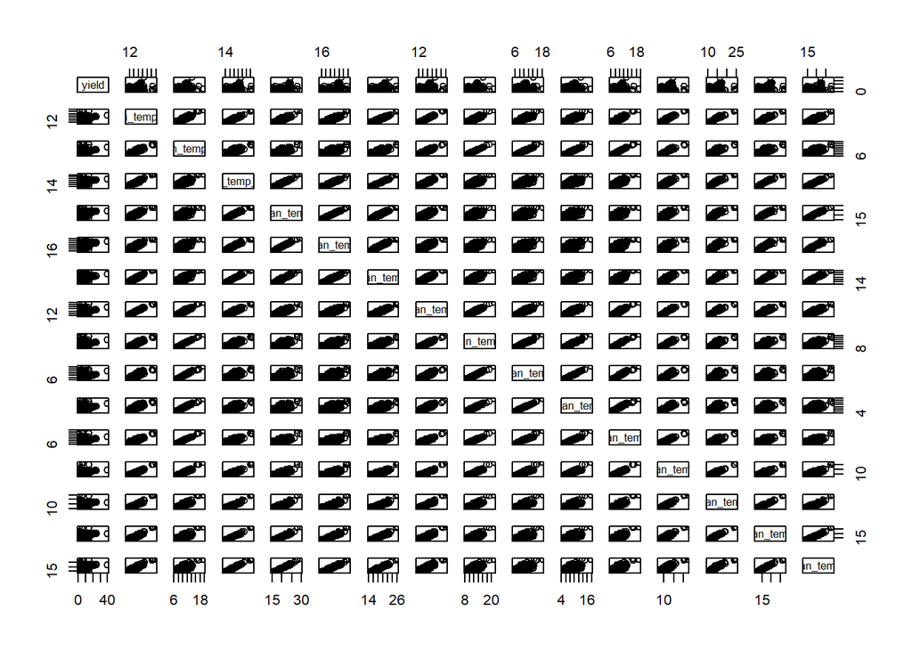

```r
yield_temp <- yield_by_region_1 %>%
  dplyr::select(yield, starts_with('lu_mean_temp'))

yield_temp %>%
  plot()
```

### Correlation Matrix - cor_temp

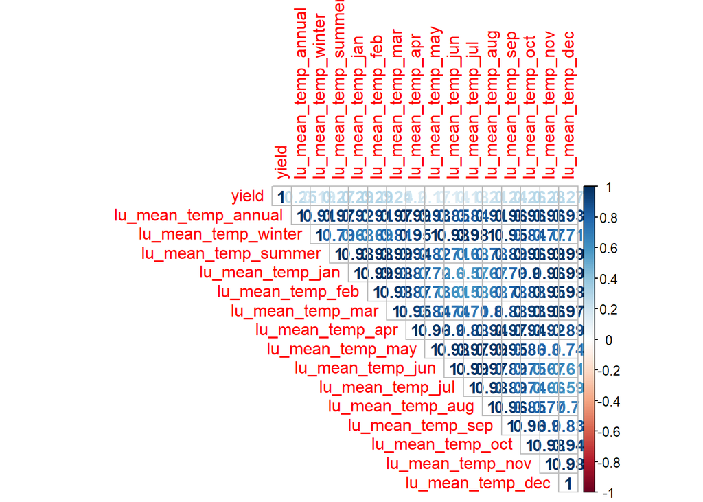

```r
cor_temp <- cor(yield_temp)
cor_temp %>%
  corrplot(method = "number", type="upper")
```

```r
# max correlation
str(cor_temp)
```

```
##  num [1:16, 1:16] 1 0.254 0.19 0.27 0.288 ...
##  - attr(*, "dimnames")=List of 2
##   ..$ : chr [1:16] "yield" "lu_mean_temp_annual" "lu_mean_temp_winter" "lu_mean_temp_summer" ...
##   ..$ : chr [1:16] "yield" "lu_mean_temp_annual" "lu_mean_temp_winter" "lu_mean_temp_summer" ...
```

The max correlation value is 0.2909265 which belongs to `lu_mean_temp_nov`.

- Observations
  - not surprisings, the temperature of one month has high correlations with that of the next,
  - with the strength decreasing over months
  - Implications
  - the temperature data should only be included in the model as one variable, since all temperature
  - variables are correlated, causing multicollinearity problem to the model

## Correlation Exploration - Yield and All Temperatures

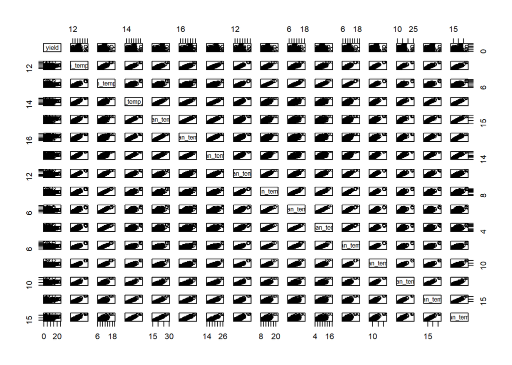

```r
yield_by_region_1 %>%
  dplyr::filter(yield < max(yield)) %>%
  dplyr::select(yield, starts_with('lu_mean_temp')) %>%
  plot()
```

- Observations
  - There is one outlier which is significant, which belongs to state `WA`
  - The outlier yield value is 39.38
  - The next biggest yield value is 24.6

## Correlation Exploration - Rain Months

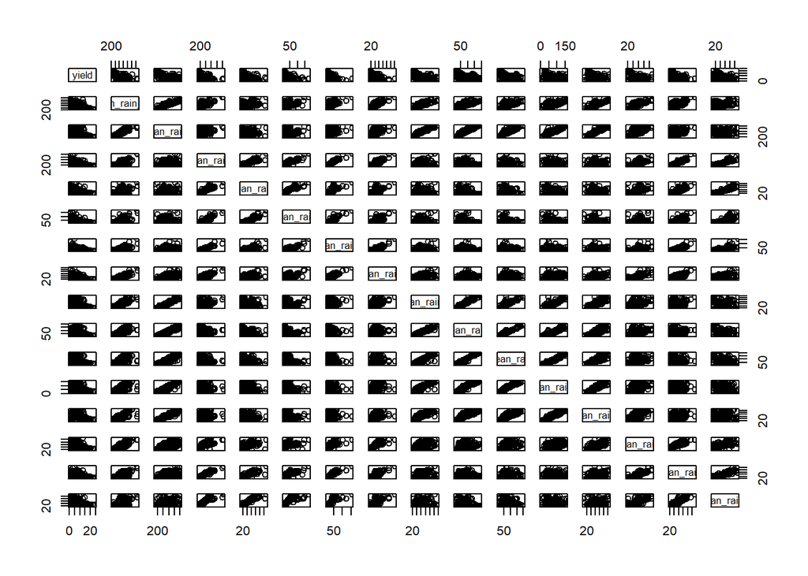

```r
yield_rain <- yield_by_region_1 %>%
  dplyr::filter(yield < max(yield)) %>%
  dplyr::select(yield, starts_with('lu_mean_rain'))
yield_rain %>%
  plot()
```

### Correlation Matrix - cor_rain

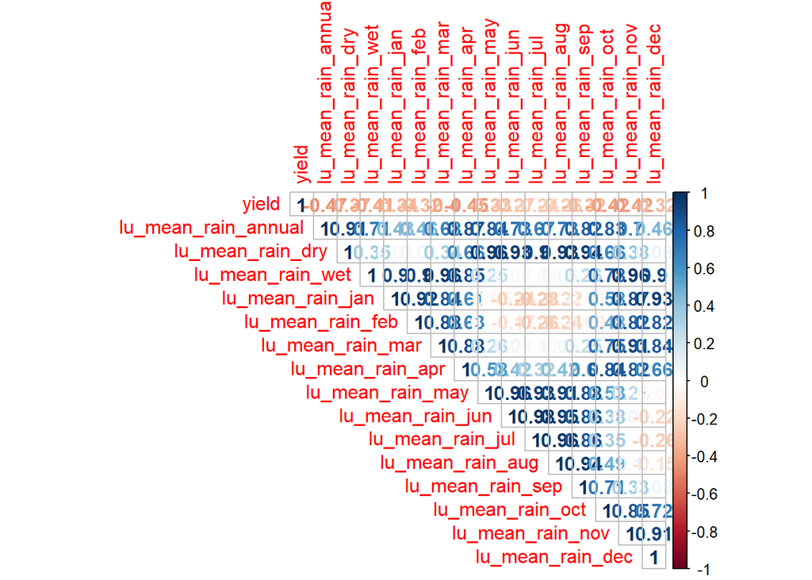

```r
cor_rain <- cor(yield_rain)
cor_rain %>%
  corrplot(method = "number", type="upper")
```

```r
# max correlation
str(cor_rain)
```

```
##  num [1:16, 1:16] 1 -0.466 -0.374 -0.406 -0.34 ...
##  - attr(*, "dimnames")=List of 2
##   ..$ : chr [1:16] "yield" "lu_mean_rain_annual" "lu_mean_rain_dry" "lu_mean_rain_wet" ...
##   ..$ : chr [1:16] "yield" "lu_mean_rain_annual" "lu_mean_rain_dry" "lu_mean_rain_wet" ...
```

## Correlation Exploration - Solar Variables

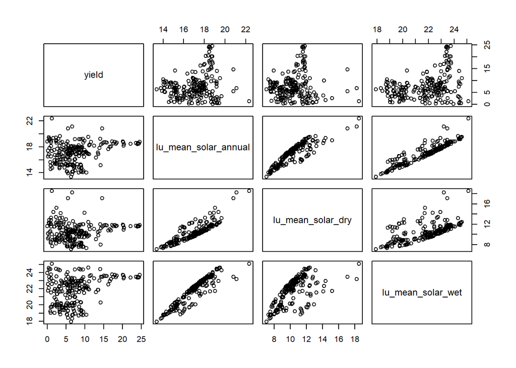

```r
yield_solar <- yield_by_region_1 %>%
  dplyr::filter(yield < max(yield)) %>%
  dplyr::select(yield, starts_with('lu_mean_solar'))
yield_solar %>%
  plot()
```

### Correlation Matrix - cor_solar

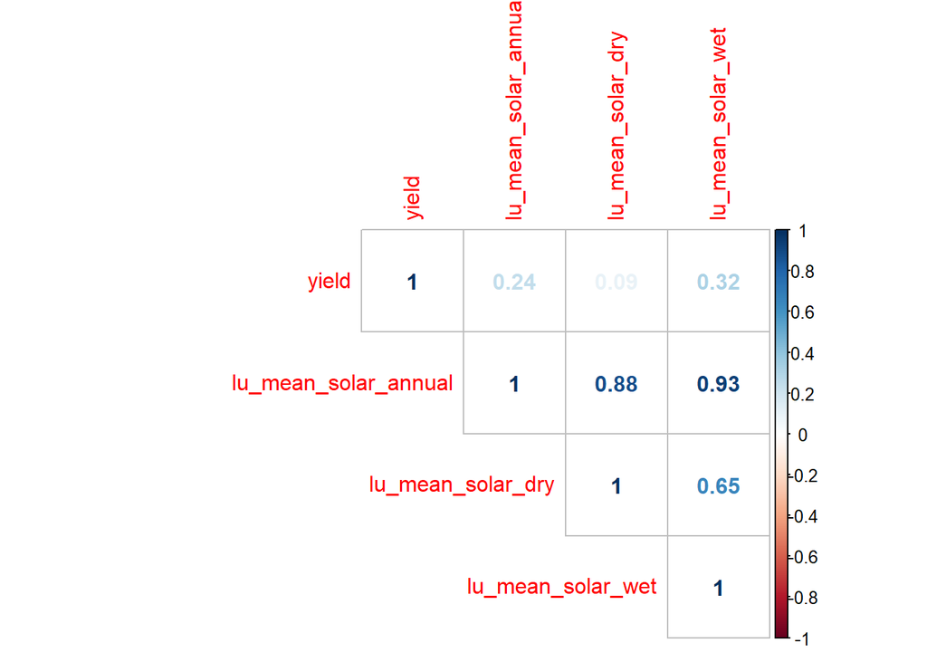

```r
# correlation matrix
cor_solar <- cor(yield_solar)
cor_solar %>%
  corrplot(method = "number", type="upper")
```

```r
# max correlation
str(cor_solar)
```

```
##  num [1:4, 1:4] 1 0.2401 0.0937 0.3159 0.2401 ...
##  - attr(*, "dimnames")=List of 2
##   ..$ : chr [1:4] "yield" "lu_mean_solar_annual" "lu_mean_solar_dry" "lu_mean_solar_wet"
##   ..$ : chr [1:4] "yield" "lu_mean_solar_annual" "lu_mean_solar_dry" "lu_mean_solar_wet"
```

- Observations
  - Max correlation with Yield: 0.3158646 which is from `lu_mean_solar_wet`

## Correlation Exploration - Soil Variables

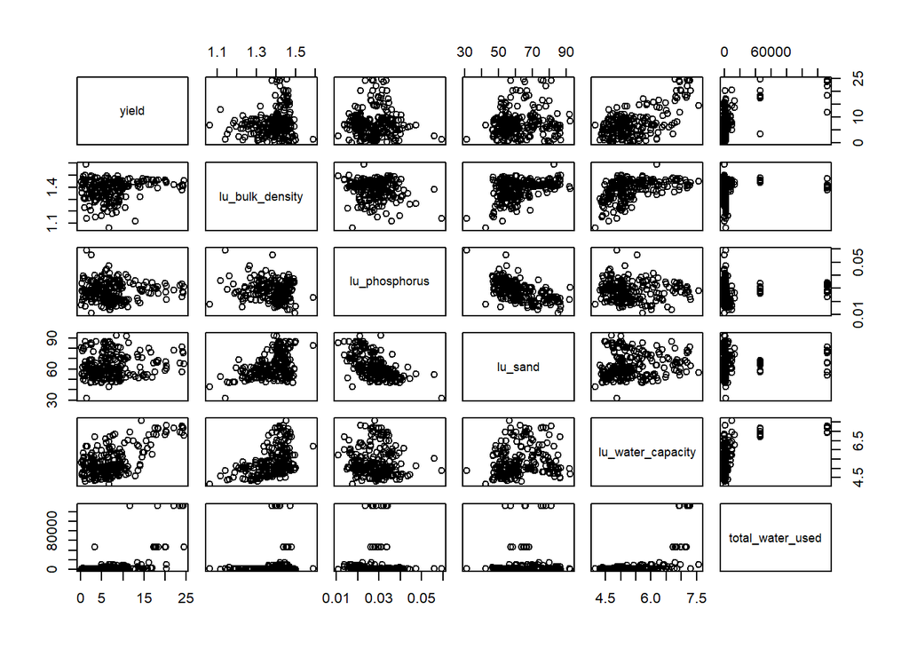

```r
yield_soil <- yield_by_region_1 %>%
  dplyr::filter(yield < max(yield)) %>%
  dplyr::select(yield, lu_bulk_density
                # , lu_carbon     # correlated with lu_water_capacity
                # , lu_clay       # correlated with lu_sand
                # , lu_nitrogen   # correlated with lu_water_capacity
                # , lu_ph          # correlated with lu_water_capacity
                , lu_phosphorus
                , lu_sand
                # , lu_silt       # correlated with lu_sand
                , lu_water_capacity
                ,total_water_used
                )
yield_soil %>%
  plot()
```

### Correlation Matrix - cor_soil

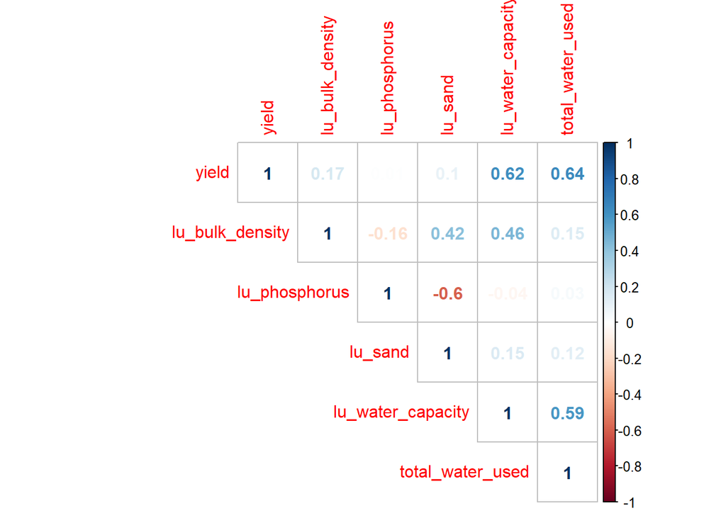

```r
cor_soil <- cor(yield_soil)
cor_soil %>%
  corrplot(method = "number", type="upper")
```

```r
# max correlation
str(cor_soil)
```

```
##  num [1:6, 1:6] 1 0.17484 0.00926 0.09738 0.619 ...
##  - attr(*, "dimnames")=List of 2
##   ..$ : chr [1:6] "yield" "lu_bulk_density" "lu_phosphorus" "lu_sand" ...
##   ..$ : chr [1:6] "yield" "lu_bulk_density" "lu_phosphorus" "lu_sand" ...
```

## Correlation Exploration - Combine all variables

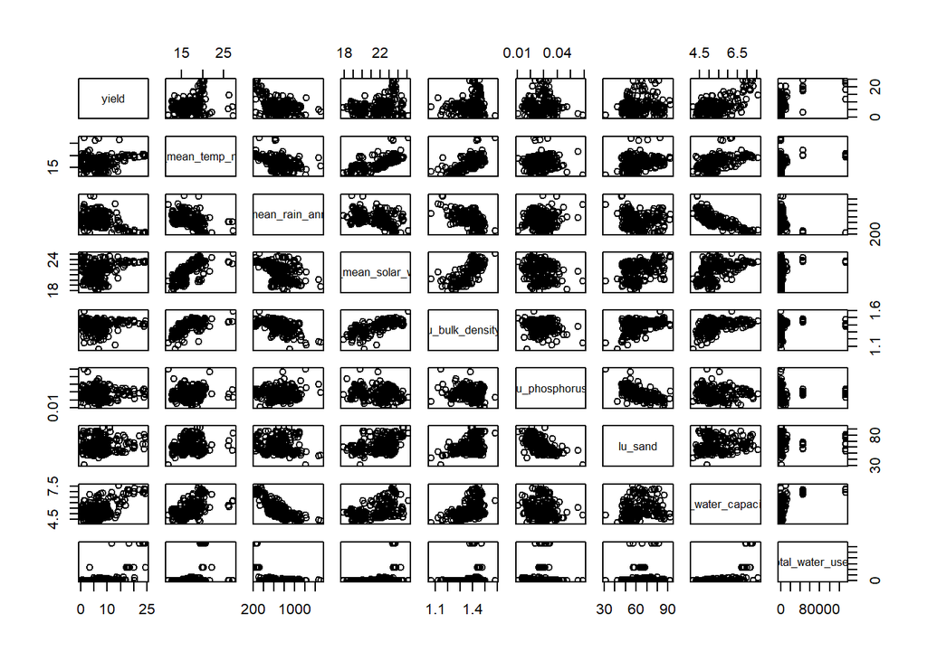

```r
yield_final <- yield_by_region_1 %>%
  dplyr::filter(yield < max(yield)) %>%
  dplyr::select(yield
                ,lu_mean_temp_nov
                ,lu_mean_rain_annual
                ,lu_mean_solar_wet
                , lu_bulk_density
                # , lu_carbon     # correlated with lu_water_capacity
                # , lu_clay       # correlated with lu_sand
                # , lu_nitrogen   # correlated with lu_water_capacity
                # , lu_ph          # correlated with lu_water_capacity
                , lu_phosphorus
                , lu_sand
                # , lu_silt       # correlated with lu_sand
                , lu_water_capacity
                ,total_water_used
  )
yield_final %>%
  plot()
```

### Correlation Matrix - cor_soil

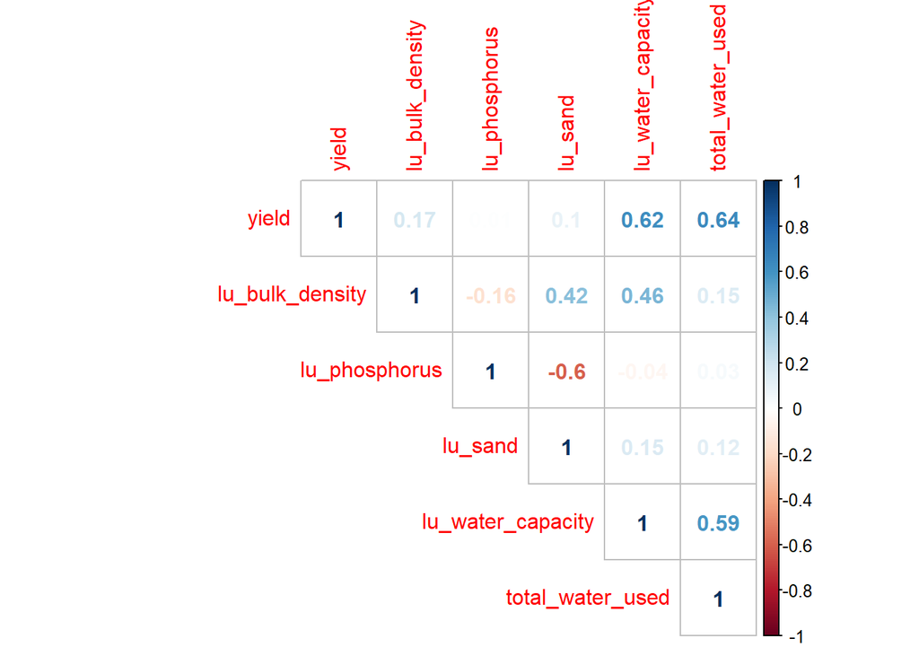

```r
# correlation matrix
cor_soil <- cor(yield_soil)
cor_soil %>%
  corrplot(method = "number", type="upper")
```

# Plotting

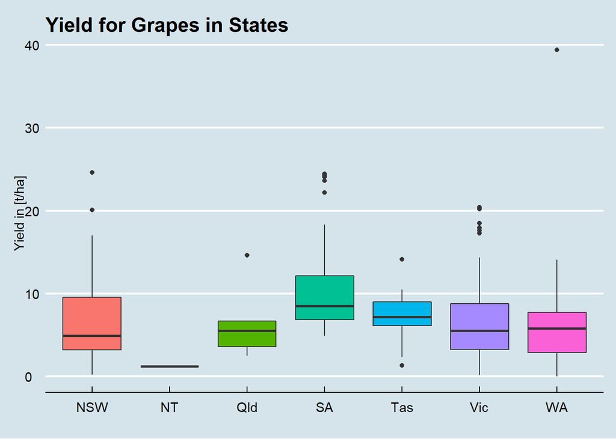

```r
ggplot(yield_by_region_1) +
  geom_boxplot(mapping = aes(x = state, y = yield, fill=state), show.legend = FALSE) +
  xlab("") +
  ylab("Yield in [t/ha]") +
  ggtitle("Yield for Grapes in States") +
  theme_economist()
```

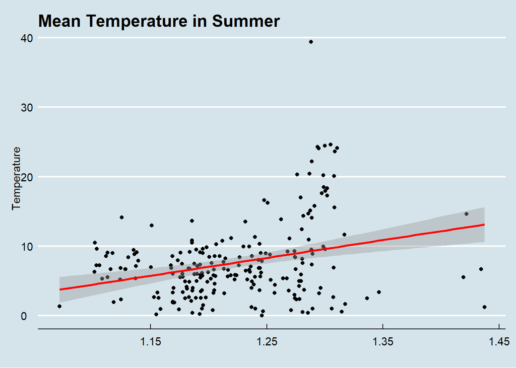

```r
yield_plot <- yield_by_region_1 %>%
  mutate(lu_mean_temp_nov_sqrt = sqrt(lu_mean_temp_nov)
         ,lu_mean_temp_nov_log = log10(lu_mean_temp_nov)
         )

ggplot(yield_plot) +
  geom_point(aes(x = lu_mean_temp_nov_log, y = yield, fill=lu_mean_temp_nov_log)
             ,show.legend = FALSE) +
  stat_smooth(aes(x = lu_mean_temp_nov_log, y = yield), method = "lm", col = "red") +
  xlab("") +
  ylab("Temperature") +
  ggtitle("Mean Temperature in Summer") +
  theme_economist()
```

# Modeling

## Model 1

```r
yield_by_region_1 <- yield_by_region_1 %>%
  filter(state == 'NSW' | state == 'WA' | state == 'Tas' | state =='Vic' | state =='SA') %>%
  filter(yield < max(yield)) %>%
  dplyr::select(yield
                ,state
                ,lu_mean_temp_nov
                ,lu_mean_rain_annual
                ,lu_mean_solar_wet
                , lu_bulk_density
                # , lu_carbon     # correlated with lu_water_capacity
                # , lu_clay       # correlated with lu_sand
                # , lu_nitrogen   # correlated with lu_water_capacity
                # , lu_ph          # correlated with lu_water_capacity
                , lu_phosphorus
                , lu_sand
                # , lu_silt       # correlated with lu_sand
                , lu_water_capacity
                ,total_water_used
              )

# set train and test ----
train_size <- floor(0.7 * nrow(yield_by_region_1))

set.seed(10)
train_n <- sample(seq_len(nrow(yield_by_region_1)), size = train_size)

train <- yield_by_region_1[train_n, ]
test <- yield_by_region_1[-train_n, ]

# check sizes

nrow(yield_by_region_1) == nrow(train) + nrow(test)
```

```
## [1] TRUE
```

```r
# Diagnostics a bit more on EDA

summary(yield_by_region_1)                       # stats
```

```
##      yield           state           lu_mean_temp_nov lu_mean_rain_annual
##  Min.   : 0.040   Length:215         Min.   :11.79    Min.   : 247.4
##  1st Qu.: 3.985   Class :character   1st Qu.:15.21    1st Qu.: 541.7
##  Median : 6.670   Mode  :character   Median :16.34    Median : 668.5
##  Mean   : 7.552                      Mean   :16.70    Mean   : 688.4
##  3rd Qu.: 9.215                      3rd Qu.:18.80    3rd Qu.: 834.6
##  Max.   :24.600                      Max.   :22.21    Max.   :1507.1
##  lu_mean_solar_wet lu_bulk_density lu_phosphorus        lu_sand
##  Min.   :17.92     Min.   :1.061   Min.   :0.01092   Min.   :31.44
##  1st Qu.:20.08     1st Qu.:1.332   1st Qu.:0.02183   1st Qu.:53.86
##  Median :22.09     Median :1.402   Median :0.02789   Median :60.26
##  Mean   :21.72     Mean   :1.380   Mean   :0.02768   Mean   :62.86
##  3rd Qu.:23.01     3rd Qu.:1.441   3rd Qu.:0.03239   3rd Qu.:70.40
##  Max.   :24.62     Max.   :1.499   Max.   :0.05926   Max.   :92.37
##  lu_water_capacity total_water_used
##  Min.   :4.170     Min.   :     4.5
##  1st Qu.:4.771     1st Qu.:   256.2
##  Median :5.087     Median :  1449.5
##  Mean   :5.348     Mean   :  8333.4
##  3rd Qu.:5.738     3rd Qu.:  2190.9
##  Max.   :7.579     Max.   :132532.8
```

```r
skewness(yield_by_region_1$yield)                # skewness function [- left ; + right]
```

```
## [1] 1.282848
```

```r
# 1.747308 -- is > 0, ie it is skewed -- +ve ==> mean > median (right skewed)
kurtosis(yield_by_region_1$yield)                # skewness function [- left ; + right]
```

```
## [1] 1.645256
```

```r
# 4.739303 -- is > 0, ie it is fat-tailed

grubbs.test(yield_by_region_1$yield, type = 10, opposite = FALSE, two.sided = FALSE)
```

```
##
##  Grubbs test for one outlier
##
## data:  yield_by_region_1$yield
## G = 3.2273, U = 0.9511, p-value = 0.1181
## alternative hypothesis: highest value 24.6 is an outlier
```

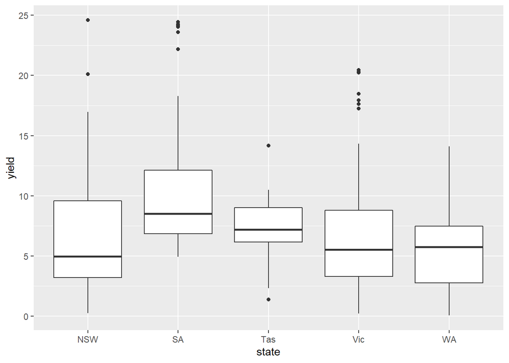

```r
# grubbs test is not appropriate since the distribution of yield is not normal
#   Grubbs test for one outlier
# data:  yield_by_region_1$yield
# G = 5.56026, U = 0.85553, p-value = 8.471e-07
# alternative hypothesis: highest value 39.38 is an outlier

# hist(yield_by_region_1$yield) -- confirms the skewness
# which.max(yield_by_region_1$yield)
# 175   # the 175th row has the highest yield
# yield_by_region_1$yield[which.max(yield_by_region_1$yield)]
# 39.38 # the value of the outlier of yield

ggplot(yield_by_region_1, aes(state, yield)) + geom_boxplot()
```

```r
# BoxPlot based outlier detection
boxB(yield_by_region_1$yield, k=1.5, method='resistant', weights=NULL, id=NULL,
     exclude=NA, logt=FALSE)
```

```
## No. of outliers in left tail: 0
```

```
## No. of outliers in right tail: 16
```

```
## $quartiles
##   25%   50%   75%
## 3.985 6.670 9.215
##
## $fences
## lower upper
## -3.86 17.06
##
## $excluded
## integer(0)
##
## $outliers
##  [1]  24  25  99 100 101 102 103 104 106 151 152 153 154 157 158 160
```

```r
# No. of outliers in left tail: 0
# No. of outliers in right tail: 17
# $quartiles
# 25%    50%    75%
# 3.9925 6.6750 9.2650
# $fences
# lower    upper
# -3.91625 17.17375
# $excluded
# integer(0)
# $outliers
# [1]  24  25  99 100 101 102 103 104 106 151 152 153 154 157 158 160 175
boxB(yield_by_region_1$yield, k=1.5, method='adjbox', weights=NULL, id=NULL,exclude=NA, logt=FALSE)
```

```
## The MedCouple skewness measure is: 0.0966
```

```
## No. of outliers in left tail: 0
```

```
## No. of outliers in right tail: 11
```

```
## $quartiles
##   25%   50%   75%
## 3.985 6.670 9.215
##
## $fences
##     lower     upper
## -1.345545 19.697358
##
## $excluded
## integer(0)
##
## $outliers
##  [1]  24  25 102 103 106 151 153 154 157 158 160
```

```r
# Character, identifies the method to be used: method="resistant" provides the
# ‘standard’ boxplot fences; method="asymmetric" is a modification of standard
# method to deal with (moderately) skewed data; method="adjbox" uses Hubert
# and Vandervieren (2008) adjusted boxplot for skewed distributions.

##############
# Skewness and Kurtosis tests on predictor variables
skewness(yield_by_region_1$lu_mean_temp_nov)
```

```
## [1] 0.07418445
```

```r
# -0.07095177 -- is close to 0, ie it is not skewed -- -ve ==> mean < median (left skewed)
kurtosis(yield_by_region_1$lu_mean_temp_nov)
```

```
## [1] -0.912811
```

```r
# -0.8545006 -- is close to 0, ie it is not flat or thin tailed -- -ve ==> thin-tailed
skewness(yield_by_region_1$lu_mean_rain_annual)
```

```
## [1] 0.3071481
```

```r
# 0.3034638 -- is close to 0, ie it is not skewed -- -ve ==> mean < median (left skewed)
kurtosis(yield_by_region_1$lu_mean_rain_annual)
```

```
## [1] 0.2235864
```

```r
# 0.2340328 -- is close to 0, ie it is not flat or thin tailed -- -ve ==> thin-tailed
skewness(yield_by_region_1$lu_mean_solar_wet)
```

```
## [1] -0.3173665
```

```r
# -0.3142641 -- is close to 0, ie it is not skewed -- -ve ==> mean < median (left skewed)
kurtosis(yield_by_region_1$lu_mean_solar_wet)
```

```
## [1] -1.092304
```

```r
# -0.9238899 -- is close to 0, ie it is not flat or thin tailed -- -ve ==> thin-tailed
# Skewness and Kurtosis tests on predictor variables
skewness(yield_by_region_1$lu_bulk_density)
```

```
## [1] -1.127059
```

```r
# -0.07095177 -- is close to 0, ie it is not skewed -- -ve ==> mean < median (left skewed)
kurtosis(yield_by_region_1$lu_bulk_density)
```

```
## [1] 1.131768
```

```r
# -0.8545006 -- is close to 0, ie it is not flat or thin tailed -- -ve ==> thin-tailed
skewness(yield_by_region_1$lu_phosphorus)
```

```
## [1] 0.4701025
```

```r
# 0.3034638 -- is close to 0, ie it is not skewed -- -ve ==> mean < median (left skewed)
kurtosis(yield_by_region_1$lu_phosphorus)
```

```
## [1] 0.7439774
```

```r
# 0.2340328 -- is close to 0, ie it is not flat or thin tailed -- -ve ==> thin-tailed
skewness(yield_by_region_1$lu_sand)
```

```
## [1] 0.5311693
```

```r
# -0.3142641 -- is close to 0, ie it is not skewed -- -ve ==> mean < median (left skewed)
kurtosis(yield_by_region_1$lu_sand)
```

```
## [1] -0.4813566
```

```r
# -0.9238899 -- is close to 0, ie it is not flat or thin tailed -- -ve ==> thin-tailed
# Skewness and Kurtosis tests on predictor variables
skewness(yield_by_region_1$lu_water_capacity)
```

```
## [1] 1.02589
```

```r
# -0.07095177 -- is close to 0, ie it is not skewed -- -ve ==> mean < median (left skewed)
kurtosis(yield_by_region_1$lu_water_capacity)
```

```
## [1] 0.1625968
```

```r
# -0.8545006 -- is close to 0, ie it is not flat or thin tailed -- -ve ==> thin-tailed
skewness(yield_by_region_1$total_water_used)
```

```
## [1] 4.16074
```

```r
# 0.3034638 -- is close to 0, ie it is not skewed -- -ve ==> mean < median (left skewed)
kurtosis(yield_by_region_1$total_water_used)
```

```
## [1] 16.61484
```

```r
# 0.2340328 -- is close to 0, ie it is not flat or thin tailed -- -ve ==> thin-tailed
#######


x <- model.matrix(~., train[,!(colnames(train) == "yield")]) # Lasso Regularization Algorithm
y <- train$yield
cv.out <- cv.glmnet(x, y, alpha=1, type.measure = "mse" )
lambda_min <- cv.out$lambda.min
lambda_1se <- cv.out$lambda.1se
coef <- as.matrix(coef(cv.out,s=lambda_1se))
coef2 <- as.data.frame(as.table(coef))
coef2 <- coef2 %>%
         dplyr::select(-Var2) %>%
         filter(Freq != 0) %>%
         rename(Variable = Var1, Coeficients = Freq)
```

```r
coef2
```

| Variable | Coeficients |
| --- | --- |
| (Intercept) | -3.575160e+00 |
| lu_water_capacity | 2.029134e+00 |
| total_water_used | 7.057598e-05 |

The output shows that only those variables that had been determined to be significant on the basis of p-values have non-zero coefficients. The coefficients of all other variables have been set to zero by the algorithm.

# Method 1

# Select and Fit for Variables

```r
train1 <- train # %>%
  # dplyr::select(lon:total_water_used)

train1$lgYield <- sqrt(train1$yield)

test1 <- test

fit_select <- glm(
                # yield ~
                yield ~
                lu_mean_temp_nov +
                lu_mean_rain_annual +
                lu_mean_solar_wet +
                lu_bulk_density +
                lu_phosphorus +
                lu_sand +
                lu_water_capacity +
                total_water_used
               # family = inverse.gaussian(link = "log"),
               # family = inverse.gaussian(link = "1/mu^2"),
               # family = Gamma(link = "log"),             # 648.46
               # family = Gamma(link = "inverse"),
               ,family = gaussian(link = "identity"),

               data = train1)

# Family            Default Link Function
# binomial          (link = "logit")
# gaussian          (link = "identity")
# Gamma             (link = "inverse")  -- or identity, log
# inverse.gaussian  (link = "1/mu^2")
# poisson           (link = "log")  -- or identity or sqrt
# quasi             (link = "identity", variance = "constant")
# quasibinomial     (link = "logit")
# quasipoisson      (link = "log")
```

```r
summary(fit_select) # Stats
```

```
##
## Call:
## glm(formula = yield ~ lu_mean_temp_nov + lu_mean_rain_annual +
##     lu_mean_solar_wet + lu_bulk_density + lu_phosphorus + lu_sand +
##     lu_water_capacity + total_water_used, family = gaussian(link = "identity"),
##     data = train1)
##
## Deviance Residuals:
##     Min       1Q   Median       3Q      Max
## -7.3847  -1.9093   0.0775   1.9197   8.6086
##
## Coefficients:
##                       Estimate Std. Error t value Pr(>|t|)
## (Intercept)         -5.775e+00  8.946e+00  -0.646   0.5196
## lu_mean_temp_nov    -3.359e-01  2.400e-01  -1.400   0.1638
## lu_mean_rain_annual -5.841e-04  2.429e-03  -0.240   0.8103
## lu_mean_solar_wet    5.385e-01  3.171e-01   1.698   0.0917 .
## lu_bulk_density     -9.884e+00  6.963e+00  -1.420   0.1579
## lu_phosphorus        6.395e+01  5.565e+01   1.149   0.2524
## lu_sand              1.953e-02  3.550e-02   0.550   0.5831
## lu_water_capacity    3.353e+00  7.706e-01   4.351 2.58e-05 ***
## total_water_used     9.339e-05  1.548e-05   6.032 1.35e-08 ***
## ---
## Signif. codes:  0 '***' 0.001 '**' 0.01 '*' 0.05 '.' 0.1 ' ' 1
##
## (Dispersion parameter for gaussian family taken to be 11.78636)
##
##     Null deviance: 4290.2  on 149  degrees of freedom
## Residual deviance: 1661.9  on 141  degrees of freedom
## AIC: 806.44
##
## Number of Fisher Scoring iterations: 2
```

```r
# original AIC: 811.79
# lu_clay * lu_silt AIC: 811.5
# lu_clay * lu_silt * total_water_used  AIC: 807.76
# lu_clay * lu_silt * total_water_used  AIC: 807.76
# lu_rain mar : aug AIC: 642.08

# confidence intervals for the coefficients
confint(fit_select)
```

```
##                             2.5 %       97.5 %
## (Intercept)         -2.330886e+01 1.175828e+01
## lu_mean_temp_nov    -8.063049e-01 1.344850e-01
## lu_mean_rain_annual -5.344235e-03 4.176039e-03
## lu_mean_solar_wet   -8.306793e-02 1.159985e+00
## lu_bulk_density     -2.353090e+01 3.762750e+00
## lu_phosphorus       -4.512318e+01 1.730208e+02
## lu_sand             -5.005332e-02 8.911164e-02
## lu_water_capacity    1.843017e+00 4.863883e+00
## total_water_used     6.304392e-05 1.237394e-04
```

```r
vif(fit_select) # Retain model if vif (Variable Inflation Factors) of each feature is below 5.
```

```
##    lu_mean_temp_nov lu_mean_rain_annual   lu_mean_solar_wet     lu_bulk_density
##            3.408530            3.490013            3.603825            3.511106
##       lu_phosphorus             lu_sand   lu_water_capacity    total_water_used
##            1.775445            2.183073            3.934127            1.851892
```

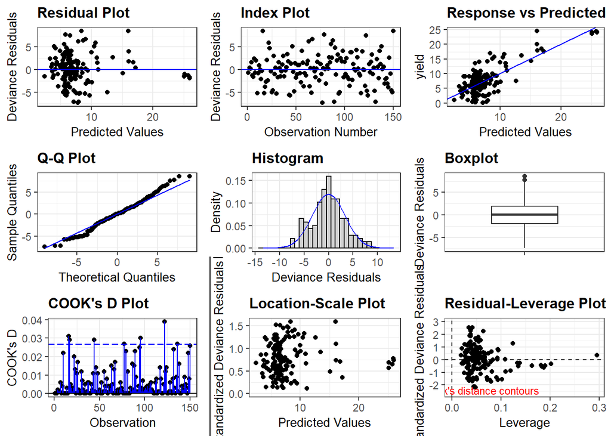

```r
resid_panel(fit_select, plots = "all") # Diagnostic Plots
```

```r
train1$residuals <- residuals(fit_select) # Calculate residuals values of model for training data

train1$predicted <- predict(fit_select, train1, type="response") # Calculate predicted values of model for training data

rmse_train1 <- sqrt(mean(train1$residuals ** 2)) # Root Mean Squared Error for training data

test1$predicted <- predict(fit_select, test1) # Calculate residuals values of model for training data

test1$residuals <- test1$yield - test1$predicted #  Calculate residuals values of model for test data

rmse_test1 <- sqrt(mean(test1$residuals ** 2)) # Root Mean Squared Error for test data
```

Method 1 RMSE comparison: + rmse: 4.4052178 + Check RMSEs shouldnt exceed 15% of each other: 0.7555905

# Method 2

```r
train_feat <- train %>%
#  dplyr::select(lon:total_water_used, -yield)
  dplyr::select(-yield)

trainX <- train            # [, c("lat","lu_mean_temp_jan")]
# trainX <- dplyr::select(train, lon:lu_mean_rain_aug, -yield)
trainY <- train$yield


# setup trainControl object
control <- trainControl(  method = "cv",              # cross-validation
                          number = 10,                 # 5 folds
                          savePredictions = "final",
                          allowParallel = TRUE
)

# setup modelling parameters and run ----
fit <- train(
                # x = train_feat,
  yield ~

    # lon +
    # lat +
    # lu_mean_temp_jan +
    # lu_mean_temp_feb +
    # lu_mean_temp_mar +
    # lu_mean_temp_apr +
    # lu_mean_temp_may +
    # lu_mean_temp_jun +
    # lu_mean_temp_jul +
    # lu_mean_temp_aug +
    # lu_mean_temp_sep +
    # lu_mean_temp_oct +
    lu_mean_temp_nov +
    # lu_mean_temp_dec +
    lu_mean_rain_annual +
    # lu_mean_rain_jan +
    # lu_mean_rain_feb +
    # lu_mean_rain_mar +
    # lu_mean_rain_apr +
    # lu_mean_rain_may +
    # lu_mean_rain_jun +
    # lu_mean_rain_jul +
    # lu_mean_rain_aug +
    # lu_mean_rain_sep +
    # lu_mean_rain_oct +
    # lu_mean_rain_nov +
    # lu_mean_rain_dec +

    # lu_mean_solar_annual +
    # lu_mean_solar_dry +
    lu_mean_solar_wet +
    lu_bulk_density +
    # lu_carbon +
    # lu_clay +
    # lu_nitrogen +
    # lu_ph +
    lu_phosphorus +
    lu_sand +
    # lu_silt +
    # lu_clay +
    # lu_clay * lu_silt * total_water_used,
    # lu_clay * lu_silt +
    lu_water_capacity +
    total_water_used,
  # y = trainY,
        data = train,
        method = "glm",
                metric = "RMSE",
                # trControl = trainControl(method = "cv",number=5),
                trControl = control
                ,family = "Gamma"
                , preProc = c("center","scale")
)

print(fit)
```

```
## Generalized Linear Model
##
## 150 samples
##   8 predictor
##
## Pre-processing: centered (8), scaled (8)
## Resampling: Cross-Validated (10 fold)
## Summary of sample sizes: 136, 136, 134, 137, 135, 134, ...
## Resampling results:
##
##   RMSE      Rsquared  MAE
##   3.935742  0.488767  2.969031
```

```r
summary(fit)
```

```
##
## Call:
## NULL
##
## Deviance Residuals:
##     Min       1Q   Median       3Q      Max
## -2.9028  -0.3535   0.0167   0.2937   1.0244
##
## Coefficients:
##                      Estimate Std. Error t value Pr(>|t|)
## (Intercept)          0.149349   0.006437  23.203  < 2e-16 ***
## lu_mean_temp_nov     0.018426   0.012552   1.468 0.144348
## lu_mean_rain_annual  0.008817   0.011301   0.780 0.436614
## lu_mean_solar_wet   -0.025387   0.013294  -1.910 0.058215 .
## lu_bulk_density      0.015117   0.011386   1.328 0.186427
## lu_phosphorus       -0.007077   0.007730  -0.916 0.361455
## lu_sand             -0.002889   0.007832  -0.369 0.712790
## lu_water_capacity   -0.032970   0.008504  -3.877 0.000161 ***
## total_water_used    -0.002728   0.004052  -0.673 0.501958
## ---
## Signif. codes:  0 '***' 0.001 '**' 0.01 '*' 0.05 '.' 0.1 ' ' 1
##
## (Dispersion parameter for Gamma family taken to be 0.2620165)
##
##     Null deviance: 94.631  on 149  degrees of freedom
## Residual deviance: 68.377  on 141  degrees of freedom
## AIC: 857.05
##
## Number of Fisher Scoring iterations: 5
```

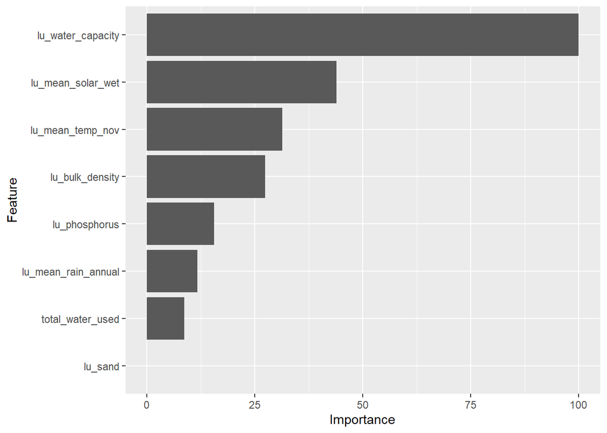

```r
# plot variable importance
ggplot(varImp(fit))
```

```r
# predict on our test set ----
test_feat <- test

pred <- predict(fit, test_feat)

# calculate rmse and scatter index
rmse <- rmse(pred, test$yield)
SI <- rmse/mean(yield_by_region_1$yield)
```

Method 2 RMSE comparison: + rmse: 4.0684831 + SI: 0.538696 + (predicted / trained): 0.9673732